# FML_3rd_Assignment

Venkata Sai Reddy

23-02-2025

## Installing Necessary Packages

```r
 #install.packages("class")
 #install.packages("caret")
 #install.packages("tinytex")
 #install.packages("e1071")
 #install.packages("readr")
```

## Loading Necessary Libraries

```r
library(class)  # For k-NN classification
library(caret)  # For data pre-processing and evaluation
library(tinytex)  # For document generation
library(e1071)  # For additional ML functions
library(readr)  # To read CSV file
```

# Question 1: Importing and Preparing Data

## Loading the Dataset

```r
#Reading the vehicle sales file

Vehicles_data <- read.csv("C:/Rstudio I&D/Vehicles_Sales.csv")
```

```r
dim(Vehicles_data)
```

```
## [1] 2677   12
```

## Data Cleaning and Preparation

```r
#Dropping YEAR_ID and PRODUCTLINE

Vehicles_data<-Vehicles_data[,-c(9,10)]

dim(Vehicles_data)
```

```
## [1] 2677   10
```

### Interpretation

Removed the YEAR_ID and PRODUCTLINE from the dataset as mentioned in the question and stored in Vehicles_data

```r
# Transforming the categorical variables into dummy variables.

# Only DEALSIZE needs to be converted to factor
Vehicles_data$DEALSIZE<-as.factor(Vehicles_data$DEALSIZE)

# now, convert DEALSIZE to dummy variables
groups <- dummyVars(~., data = Vehicles_data)

# Create Dummy variable.names
Vehicles_data <- as.data.frame(predict(groups, Vehicles_data))

head(Vehicles_data)
```

```
##   ORDERNUMBER QUANTITYORDERED PRICEEACH ORDERLINENUMBER   SALES STATUS QTR_ID
## 1       10107              30     95.70               2 2871.00      1      1
## 2       10121              34     81.35               5 2765.90      1      2
## 3       10134              41     94.74               2 3884.34      1      3
## 4       10145              45     83.26               6 3746.70      1      3
## 5       10159              49    100.00              14 5205.27      1      4
## 6       10168              36     96.66               1 3479.76      1      4
##   MONTH_ID MSRP DEALSIZE.Large DEALSIZE.Medium DEALSIZE.Small
## 1        2   95              0               0              1
## 2        5   95              0               0              1
## 3        7   95              0               1              0
## 4        8   95              0               1              0
## 5       10   95              0               1              0
## 6       10   95              0               1              0
```

### Interpretation

As DEALSIZE is stored as categorical variable. so used dummyvars()function and firstly converted DEALSIZE variable alone into factors then converted into dummy variables.

# Question 1: Splitting Dataset into Training, Validation, and Testing Sets

## Partitioning Data

```r
#set seed to ensure reproducibility of results
set.seed(1)

# Sample 50% for training
training_indices <- sample(row.names(Vehicles_data), 0.5 * dim(Vehicles_data)[1])

train.df<-Vehicles_data[training_indices,]

dim(train.df)
```

```
## [1] 1338   12
```

```r
# Get remaining data after splitting for training
remaining_data <- setdiff(row.names(Vehicles_data), training_indices)
```

```r
# Sample 60% of remaining data for validation (30% of total dataset)
validation_indices <- sample(remaining_data, 0.6 * length(remaining_data))
valid.df <- Vehicles_data[validation_indices,]
dim(valid.df)
```

```
## [1] 803  12
```

```r
# The remaining 40% goes into the test set (20% of total dataset)
testing_indices <- setdiff(remaining_data, validation_indices)
test.df<-Vehicles_data[testing_indices,]

dim(test.df)
```

```
## [1] 536  12
```

```r
# Excluding the target variable(Status) from normalization process

train.norm.df <- train.df[,-6]
valid.norm.df <- valid.df[,-6]
test.norm.df <- test.df[,-6]

colnames(train.norm.df)
```

```
##  [1] "ORDERNUMBER"     "QUANTITYORDERED" "PRICEEACH"       "ORDERLINENUMBER"
##  [5] "SALES"           "QTR_ID"          "MONTH_ID"        "MSRP"
##  [9] "DEALSIZE.Large"  "DEALSIZE.Medium" "DEALSIZE.Small"
```

```r
#normalize the train, valid and test data records

norm.values <- preProcess(train.df[, -6], method=c("center", "scale"))
train.norm.df <- predict(norm.values, train.df[, -6])
valid.norm.df <- predict(norm.values, valid.df[, -6])
test.norm.df <- predict(norm.values, test.df[, -6])
```

```r
# Identifying duplicate entries across all three subsets

duplicates_all_sets <- intersect(intersect(train.df, valid.df), test.df)
```

### Interpretation

The Vehicles_data dataset, which is a dataset with status columns added back, is divided into three sections in the section above: 50% for training, 30% for validation, and 20% for testing and later removed the target variable(Status) and then normalized the data. duplicates_all_sets <- intersect was used to look for duplication.

# Question 2: k-NN Classification for a New Vehicle Record

```r
#adding a new sample data of new vehicle
Vehicle_Record_New<- data.frame(
  ORDERNUMBER=10322,
  QUANTITYORDERED=50,
  PRICEEACH=100,
  ORDERLINENUMBER=6,
  SALES=12536.5,
  QTR_ID=4,
  MONTH_ID=11,
  MSRP=127,
  DEALSIZE.Large=1,
  DEALSIZE.Small=0,
  DEALSIZE.Medium=0
)

#Normalizing the new data

new_vehicle_norm <- Vehicle_Record_New

new_vehicle_norm <- predict(norm.values, new_vehicle_norm)
```

### Interpretation

In the above section, a data frame for the new sample dataset is created using the specified variable values, and the data frame is normalized using the same normalization parameters as the vehicle dataset.

## Determining the Optimal k Value

```r
# Running k-NN classification with k = 1 for the new vehicle record

knn.prediction1 <- class::knn(train = train.norm.df,
                       test = new_vehicle_norm,
                       cl = train.df$STATUS, k = 1)
knn.prediction1
```

```
## [1] 1
## Levels: 0 1
```

### Interpretation

#Question 3: Finding an appropriate k value to balance between overfitting and underfitting

```r
accuracy.df <- data.frame(k = seq(1, 15, 1), overallaccuracy = rep(0, 15))
for (i in 1:15) {
  knn.pred<-class::knn(train=train.norm.df,
                       test=valid.norm.df,
                       c=train.df$STATUS, k=i)

  accuracy.df[i,2]<-confusionMatrix(knn.pred,as.factor(valid.df$STATUS),positive ="1")$overall[1]

}
which(accuracy.df[,2]==max(accuracy.df[,2]))
```

```
## [1] 3
```

### Interpretation

The k-NN model was evaluated for k. K values between 1 and 15 are used to determine the appropriate balance of overfitting to underfitting. Using k=3 closest neighbors yields the greatest classification performance for this dataset, as seen by the maximum overall accuracy attained at k=3.

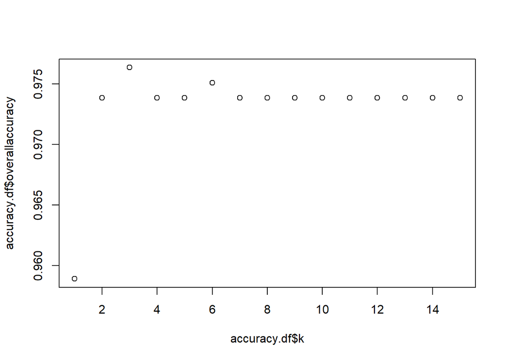

```r
# Plotting accuracy results against k values

plot(accuracy.df$k,accuracy.df$overallaccuracy)
```

```r
#new vehicle status with best suitable value 3
knn.prediction2 <- class::knn(train = train.norm.df,
                       test = new_vehicle_norm,
                       c=train.df$STATUS, k = 3)
knn.prediction2
```

```
## [1] 1
## Levels: 0 1
```

### Interpretaion

The new vehicle entry was categorized as 1 using the k-NN model using the optimum k=3, indicating that it is a member of class 1. This implies that the model forecasts the vehicle’s status as 1 with better reliability than k=1 when taking into account the three nearest neighbors.

```r
# Applying k-NN classification on the test dataset using k = 3

knn.prediction <- class::knn(train = train.norm.df,
                        test = test.norm.df,
                         c=train.df$STATUS, k = 3)

# Evaluating the model using a confusion matrix

confusionMatrix(knn.prediction, as.factor(test.df$STATUS), positive = "1")
```

```
## Confusion Matrix and Statistics
##
##           Reference
## Prediction   0   1
##          0   0   1
##          1  10 525
##
##                Accuracy : 0.9795
##                  95% CI : (0.9636, 0.9897)
##     No Information Rate : 0.9813
##     P-Value [Acc > NIR] : 0.69786
##
##                   Kappa : -0.0034
##
##  Mcnemar's Test P-Value : 0.01586
##
##             Sensitivity : 0.9981
##             Specificity : 0.0000
##          Pos Pred Value : 0.9813
##          Neg Pred Value : 0.0000
##              Prevalence : 0.9813
##          Detection Rate : 0.9795
##    Detection Prevalence : 0.9981
##       Balanced Accuracy : 0.4990
##
##        'Positive' Class : 1
##
```

### Interpretation

True Negative (TN): 0

False Positive (FP): 10

False Negative (FN): 1

True Positive (TP): 525

accuracy formula and calculation:

Accuracy = [(TP + TN) / (TP+TN+FP+FN)] * 100 = 0.9795

The Sensitivity (0.9981) indicates that the model correctly identified 99.81% of the actual positive cases (class 1). However, the Specificity (0.0000) shows that the model completely failed to identify the negative cases (class 0), meaning it predicts almost everything as positive.